# Exploratory analysis of Star_classification data

Analysis to understand better the data obtained and its characteristics. Some models will also be trained to see which one understands and classifies the data better.

Data obtained from: https://www.kaggle.com/datasets/fedesoriano/stellar-classification-dataset-sdss17

```python
import numpy as np
import pandas as pd
import matplotlib.pyplot as plt

from sklearn.model_selection import train_test_split
from sklearn.linear_model import LogisticRegression

from sklearn.utils import resample
from sklearn.ensemble import RandomForestClassifier
from sklearn import metrics, preprocessing
from sklearn.metrics import roc_auc_score, confusion_matrix, precision_recall_curve, average_precision_score,f1_score
from sklearn.preprocessing import label_binarize
from sklearn.svm import SVC

from sklearn.preprocessing import label_binarize

import shap
```

## Data Analysis

Reading the data

```python
df_ini= pd.read_csv("../data/star_classification.csv")
df_ini
```

|  | obj_ID | alpha | delta | u | g | r | i | z | run_ID | rerun_ID | cam_col | field_ID | spec_obj_ID | class | redshift | plate | MJD | fiber_ID |
| --- | --- | --- | --- | --- | --- | --- | --- | --- | --- | --- | --- | --- | --- | --- | --- | --- | --- | --- |
| 0 | 1.237661e+18 | 135.689107 | 32.494632 | 23.87882 | 22.27530 | 20.39501 | 19.16573 | 18.79371 | 3606 | 301 | 2 | 79 | 6.543777e+18 | GALAXY | 0.634794 | 5812 | 56354 | 171 |
| 1 | 1.237665e+18 | 144.826101 | 31.274185 | 24.77759 | 22.83188 | 22.58444 | 21.16812 | 21.61427 | 4518 | 301 | 5 | 119 | 1.176014e+19 | GALAXY | 0.779136 | 10445 | 58158 | 427 |
| 2 | 1.237661e+18 | 142.188790 | 35.582444 | 25.26307 | 22.66389 | 20.60976 | 19.34857 | 18.94827 | 3606 | 301 | 2 | 120 | 5.152200e+18 | GALAXY | 0.644195 | 4576 | 55592 | 299 |
| 3 | 1.237663e+18 | 338.741038 | -0.402828 | 22.13682 | 23.77656 | 21.61162 | 20.50454 | 19.25010 | 4192 | 301 | 3 | 214 | 1.030107e+19 | GALAXY | 0.932346 | 9149 | 58039 | 775 |
| 4 | 1.237680e+18 | 345.282593 | 21.183866 | 19.43718 | 17.58028 | 16.49747 | 15.97711 | 15.54461 | 8102 | 301 | 3 | 137 | 6.891865e+18 | GALAXY | 0.116123 | 6121 | 56187 | 842 |
| ... | ... | ... | ... | ... | ... | ... | ... | ... | ... | ... | ... | ... | ... | ... | ... | ... | ... | ... |
| 99995 | 1.237679e+18 | 39.620709 | -2.594074 | 22.16759 | 22.97586 | 21.90404 | 21.30548 | 20.73569 | 7778 | 301 | 2 | 581 | 1.055431e+19 | GALAXY | 0.000000 | 9374 | 57749 | 438 |
| 99996 | 1.237679e+18 | 29.493819 | 19.798874 | 22.69118 | 22.38628 | 20.45003 | 19.75759 | 19.41526 | 7917 | 301 | 1 | 289 | 8.586351e+18 | GALAXY | 0.404895 | 7626 | 56934 | 866 |
| 99997 | 1.237668e+18 | 224.587407 | 15.700707 | 21.16916 | 19.26997 | 18.20428 | 17.69034 | 17.35221 | 5314 | 301 | 4 | 308 | 3.112008e+18 | GALAXY | 0.143366 | 2764 | 54535 | 74 |
| 99998 | 1.237661e+18 | 212.268621 | 46.660365 | 25.35039 | 21.63757 | 19.91386 | 19.07254 | 18.62482 | 3650 | 301 | 4 | 131 | 7.601080e+18 | GALAXY | 0.455040 | 6751 | 56368 | 470 |
| 99999 | 1.237661e+18 | 196.896053 | 49.464643 | 22.62171 | 21.79745 | 20.60115 | 20.00959 | 19.28075 | 3650 | 301 | 4 | 60 | 8.343152e+18 | GALAXY | 0.542944 | 7410 | 57104 | 851 |

100000 rows × 18 columns

The definition of the variables can be found in the link provided but here it is a summary of the most important ones:

- obj_ID = Object Identifier,
- alpha = Right Ascension angle (at J2000 epoch)
- delta = Declination angle (at J2000 epoch)
- u = Ultraviolet filter in the photometric system
- g = Green filter in the photometric system
- r = Red filter in the photometric system
- i = Near Infrared filter in the photometric system
- z = Infrared filter in the photometric system
- class = object class (galaxy, star or quasar object)
- redshift = redshift value based on the increase in wavelength

```python
df_ini.describe()
```

|  | obj_ID | alpha | delta | u | g | r | i | z | run_ID | rerun_ID | cam_col | field_ID | spec_obj_ID | redshift | plate | MJD | fiber_ID |
| --- | --- | --- | --- | --- | --- | --- | --- | --- | --- | --- | --- | --- | --- | --- | --- | --- | --- |
| count | 1.000000e+05 | 100000.000000 | 100000.000000 | 100000.000000 | 100000.000000 | 100000.000000 | 100000.000000 | 100000.000000 | 100000.000000 | 100000.0 | 100000.000000 | 100000.000000 | 1.000000e+05 | 100000.000000 | 100000.000000 | 100000.000000 | 100000.000000 |
| mean | 1.237665e+18 | 177.629117 | 24.135305 | 21.980468 | 20.531387 | 19.645762 | 19.084854 | 18.668810 | 4481.366060 | 301.0 | 3.511610 | 186.130520 | 5.783882e+18 | 0.576661 | 5137.009660 | 55588.647500 | 449.312740 |
| std | 8.438560e+12 | 96.502241 | 19.644665 | 31.769291 | 31.750292 | 1.854760 | 1.757895 | 31.728152 | 1964.764593 | 0.0 | 1.586912 | 149.011073 | 3.324016e+18 | 0.730707 | 2952.303351 | 1808.484233 | 272.498404 |
| min | 1.237646e+18 | 0.005528 | -18.785328 | -9999.000000 | -9999.000000 | 9.822070 | 9.469903 | -9999.000000 | 109.000000 | 301.0 | 1.000000 | 11.000000 | 2.995191e+17 | -0.009971 | 266.000000 | 51608.000000 | 1.000000 |
| 25% | 1.237659e+18 | 127.518222 | 5.146771 | 20.352353 | 18.965230 | 18.135828 | 17.732285 | 17.460677 | 3187.000000 | 301.0 | 2.000000 | 82.000000 | 2.844138e+18 | 0.054517 | 2526.000000 | 54234.000000 | 221.000000 |
| 50% | 1.237663e+18 | 180.900700 | 23.645922 | 22.179135 | 21.099835 | 20.125290 | 19.405145 | 19.004595 | 4188.000000 | 301.0 | 4.000000 | 146.000000 | 5.614883e+18 | 0.424173 | 4987.000000 | 55868.500000 | 433.000000 |
| 75% | 1.237668e+18 | 233.895005 | 39.901550 | 23.687440 | 22.123767 | 21.044785 | 20.396495 | 19.921120 | 5326.000000 | 301.0 | 5.000000 | 241.000000 | 8.332144e+18 | 0.704154 | 7400.250000 | 56777.000000 | 645.000000 |
| max | 1.237681e+18 | 359.999810 | 83.000519 | 32.781390 | 31.602240 | 29.571860 | 32.141470 | 29.383740 | 8162.000000 | 301.0 | 6.000000 | 989.000000 | 1.412694e+19 | 7.011245 | 12547.000000 | 58932.000000 | 1000.000000 |

Before starting to having a look at the data, and to ensure that we don't train the model with data it has seen before, I am going to split the dataset in two parts: training and test.

```python
df_train, df_test = train_test_split(df_ini, test_size=0.25,random_state=1234)
```

```python
df_train.describe()
```

|  | obj_ID | alpha | delta | u | g | r | i | z | run_ID | rerun_ID | cam_col | field_ID | spec_obj_ID | redshift | plate | MJD | fiber_ID |
| --- | --- | --- | --- | --- | --- | --- | --- | --- | --- | --- | --- | --- | --- | --- | --- | --- | --- |
| count | 7.500000e+04 | 75000.000000 | 75000.000000 | 75000.000000 | 75000.000000 | 75000.000000 | 75000.000000 | 75000.000000 | 75000.000000 | 75000.0 | 75000.000000 | 75000.000000 | 7.500000e+04 | 75000.000000 | 75000.000000 | 75000.000000 | 75000.000000 |
| mean | 1.237665e+18 | 177.786497 | 24.144403 | 21.952907 | 20.502059 | 19.649104 | 19.088107 | 18.637578 | 4478.925533 | 301.0 | 3.511547 | 186.088653 | 5.788700e+18 | 0.576924 | 5141.288320 | 55593.079307 | 450.232613 |
| std | 8.431374e+12 | 96.398108 | 19.664895 | 36.660871 | 36.642980 | 1.851270 | 1.755401 | 36.622184 | 1963.091463 | 0.0 | 1.587167 | 148.971294 | 3.314981e+18 | 0.729507 | 2944.278074 | 1802.603174 | 272.812869 |
| min | 1.237646e+18 | 0.005528 | -18.785328 | -9999.000000 | -9999.000000 | 10.068540 | 10.008650 | -9999.000000 | 109.000000 | 301.0 | 1.000000 | 11.000000 | 2.995191e+17 | -0.009971 | 266.000000 | 51608.000000 | 1.000000 |
| 25% | 1.237659e+18 | 127.793149 | 5.128631 | 20.356005 | 18.970642 | 18.147717 | 17.742500 | 17.470398 | 3187.000000 | 301.0 | 2.000000 | 82.000000 | 2.853203e+18 | 0.055842 | 2534.000000 | 54243.000000 | 221.000000 |
| 50% | 1.237663e+18 | 181.060727 | 23.645922 | 22.184525 | 21.104725 | 20.126700 | 19.407040 | 19.005275 | 4188.000000 | 301.0 | 4.000000 | 146.000000 | 5.616147e+18 | 0.425113 | 4988.000000 | 55881.000000 | 434.000000 |
| 75% | 1.237668e+18 | 233.899669 | 39.989076 | 23.695397 | 22.124605 | 21.044810 | 20.398808 | 19.920035 | 5326.000000 | 301.0 | 5.000000 | 240.000000 | 8.324249e+18 | 0.702601 | 7393.250000 | 56772.000000 | 647.000000 |
| max | 1.237681e+18 | 359.999810 | 83.000519 | 32.781390 | 29.862580 | 27.626880 | 32.141470 | 29.383740 | 8162.000000 | 301.0 | 6.000000 | 989.000000 | 1.412694e+19 | 7.011245 | 12547.000000 | 58932.000000 | 1000.000000 |

The columns use for identifying the objects won't be considered in the study as they don't have descriptive information of the observed objects

```python
not_var=['obj_ID','field_ID','class','cam_col','run_ID','rerun_ID','spec_obj_ID','plate','MJD','fiber_ID']
```

The data doesn't seem to have many null values. They are represented by a -9999 and they seem to be only in the columns corresponding to the observational filters: u, g, r, i, z.  
This values will be replaced with the average of their corresponding columns

```python
df_train = df_train.replace(-9999,np.nan)

for cc in df_train.columns:
    if cc not in not_var:
        df_train[cc]=df_train[cc].fillna(df_train[cc].mean())
```

```python
df_train.describe()
```

|  | obj_ID | alpha | delta | u | g | r | i | z | run_ID | rerun_ID | cam_col | field_ID | spec_obj_ID | redshift | plate | MJD | fiber_ID |
| --- | --- | --- | --- | --- | --- | --- | --- | --- | --- | --- | --- | --- | --- | --- | --- | --- | --- |
| count | 7.500000e+04 | 75000.000000 | 75000.000000 | 75000.000000 | 75000.000000 | 75000.000000 | 75000.000000 | 75000.000000 | 75000.000000 | 75000.0 | 75000.000000 | 75000.000000 | 7.500000e+04 | 75000.000000 | 75000.000000 | 75000.000000 | 75000.000000 |
| mean | 1.237665e+18 | 177.786497 | 24.144403 | 22.086522 | 20.635655 | 19.649104 | 19.088107 | 18.771149 | 4478.925533 | 301.0 | 3.511547 | 186.088653 | 5.788700e+18 | 0.576924 | 5141.288320 | 55593.079307 | 450.232613 |
| std | 8.431374e+12 | 96.398108 | 19.664895 | 2.248804 | 2.033069 | 1.851270 | 1.755401 | 1.762913 | 1963.091463 | 0.0 | 1.587167 | 148.971294 | 3.314981e+18 | 0.729507 | 2944.278074 | 1802.603174 | 272.812869 |
| min | 1.237646e+18 | 0.005528 | -18.785328 | 12.101680 | 10.498200 | 10.068540 | 10.008650 | 10.225510 | 109.000000 | 301.0 | 1.000000 | 11.000000 | 2.995191e+17 | -0.009971 | 266.000000 | 51608.000000 | 1.000000 |
| 25% | 1.237659e+18 | 127.793149 | 5.128631 | 20.356053 | 18.970685 | 18.147717 | 17.742500 | 17.470520 | 3187.000000 | 301.0 | 2.000000 | 82.000000 | 2.853203e+18 | 0.055842 | 2534.000000 | 54243.000000 | 221.000000 |
| 50% | 1.237663e+18 | 181.060727 | 23.645922 | 22.184525 | 21.104725 | 20.126700 | 19.407040 | 19.005275 | 4188.000000 | 301.0 | 4.000000 | 146.000000 | 5.616147e+18 | 0.425113 | 4988.000000 | 55881.000000 | 434.000000 |
| 75% | 1.237668e+18 | 233.899669 | 39.989076 | 23.695397 | 22.124605 | 21.044810 | 20.398808 | 19.920035 | 5326.000000 | 301.0 | 5.000000 | 240.000000 | 8.324249e+18 | 0.702601 | 7393.250000 | 56772.000000 | 647.000000 |
| max | 1.237681e+18 | 359.999810 | 83.000519 | 32.781390 | 29.862580 | 27.626880 | 32.141470 | 29.383740 | 8162.000000 | 301.0 | 6.000000 | 989.000000 | 1.412694e+19 | 7.011245 | 12547.000000 | 58932.000000 | 1000.000000 |

```python
df_test = df_test.replace(-9999,np.nan)

for cc in df_test.columns:
    if cc not in not_var:
        df_test[cc]=df_test[cc].fillna(df_test[cc].mean())
```

```python
df_test.describe()
```

|  | obj_ID | alpha | delta | u | g | r | i | z | run_ID | rerun_ID | cam_col | field_ID | spec_obj_ID | redshift | plate | MJD | fiber_ID |
| --- | --- | --- | --- | --- | --- | --- | --- | --- | --- | --- | --- | --- | --- | --- | --- | --- | --- |
| count | 2.500000e+04 | 25000.000000 | 25000.000000 | 25000.000000 | 25000.000000 | 25000.000000 | 25000.000000 | 25000.000000 | 25000.000000 | 25000.0 | 25000.000000 | 25000.000000 | 2.500000e+04 | 25000.000000 | 25000.000000 | 25000.000000 | 25000.000000 |
| mean | 1.237665e+18 | 177.156975 | 24.108009 | 22.063152 | 20.619370 | 19.635736 | 19.075097 | 18.762506 | 4488.687640 | 301.0 | 3.511800 | 186.256120 | 5.769430e+18 | 0.575871 | 5124.173680 | 55575.352080 | 446.553120 |
| std | 8.460172e+12 | 96.814365 | 19.584219 | 2.257758 | 2.050227 | 1.865191 | 1.765354 | 1.775142 | 1969.796641 | 0.0 | 1.586178 | 149.133256 | 3.351002e+18 | 0.734309 | 2976.271651 | 1825.985516 | 271.539572 |
| min | 1.237646e+18 | 0.024258 | -17.205472 | 10.996230 | 10.730970 | 9.822070 | 9.469903 | 9.612333 | 109.000000 | 301.0 | 1.000000 | 11.000000 | 2.995801e+17 | -0.006055 | 266.000000 | 51608.000000 | 1.000000 |
| 25% | 1.237659e+18 | 126.764355 | 5.210496 | 20.341162 | 18.952190 | 18.106133 | 17.700250 | 17.431205 | 3180.000000 | 301.0 | 2.000000 | 82.000000 | 2.790136e+18 | 0.051552 | 2478.000000 | 54206.000000 | 220.000000 |
| 50% | 1.237663e+18 | 180.370214 | 23.645062 | 22.164815 | 21.086980 | 20.122365 | 19.398960 | 19.002635 | 4192.000000 | 301.0 | 4.000000 | 146.000000 | 5.604840e+18 | 0.420524 | 4978.000000 | 55865.000000 | 426.000000 |
| 75% | 1.237668e+18 | 233.875677 | 39.670805 | 23.662528 | 22.121780 | 21.044508 | 20.392245 | 19.924412 | 5330.000000 | 301.0 | 5.000000 | 242.000000 | 8.343351e+18 | 0.707624 | 7410.250000 | 56809.000000 | 639.000000 |
| max | 1.237681e+18 | 359.993568 | 82.947622 | 30.660390 | 31.602240 | 29.571860 | 30.250090 | 26.427790 | 8162.000000 | 301.0 | 6.000000 | 989.000000 | 1.412693e+19 | 7.011245 | 12547.000000 | 58932.000000 | 1000.000000 |

We are going to plot the variable distributions to check if there are outliers that need to be removed. The plots have the three different classes to see if there are differences between them

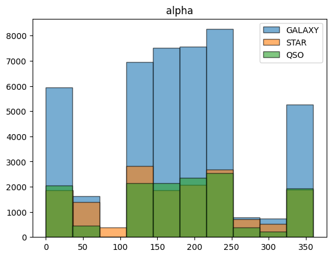

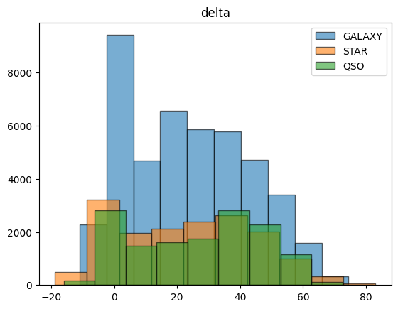

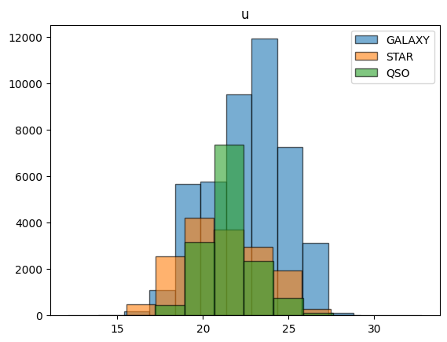

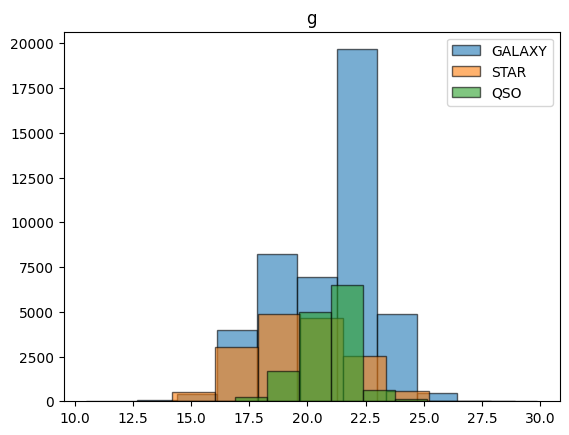

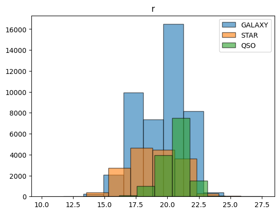

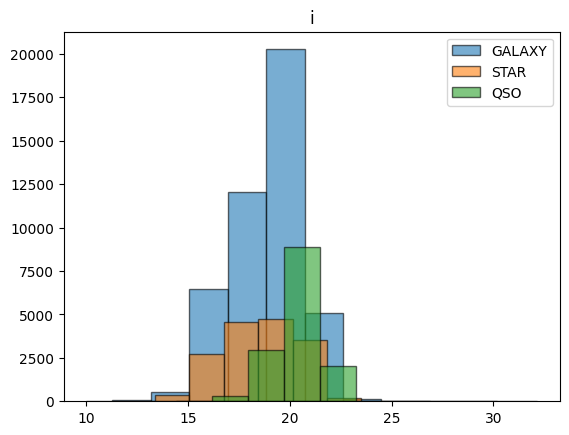

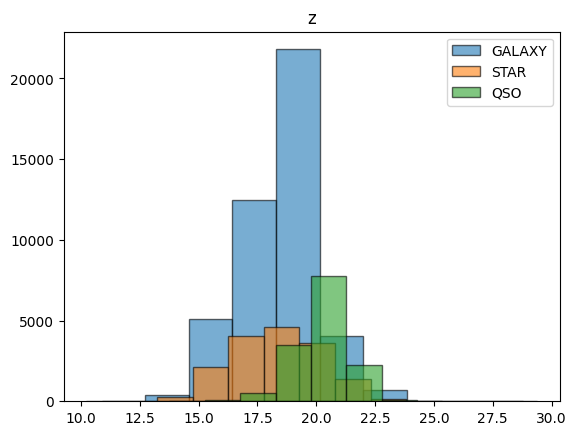

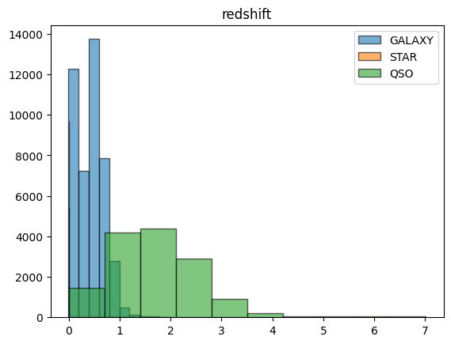

```python
for cc in df_train.columns:

    if cc not in not_var:

        for gg in ['GALAXY','STAR','QSO']:

            plt.hist(df_train[df_train['class']==gg][cc],label=gg,edgecolor='black',alpha=0.6)
        plt.legend()
        plt.title(cc)
        plt.show()
```

### Distribution of the obervations per class

Let's count the number of elements per class and to replace the strings by numbers

```python
df_train[['obj_ID','class']].groupby('class').count()
```

| class | obj_ID |
| --- | --- |
| GALAXY | 44621 |
| QSO | 14206 |
| STAR | 16173 |

```python
cat= ['STAR','GALAXY','QSO']
for elem in enumerate(cat):
    df_train = df_train.replace(elem[1], elem[0])
    df_test = df_test.replace(elem[1], elem[0])

df_train[['obj_ID','class']].groupby('class').count()
```

| class | obj_ID |
| --- | --- |
| 0 | 16173 |
| 1 | 44621 |
| 2 | 14206 |

The data set is not balanced, there are many more galaxies than stars or QSO so we need to balance the dataset before training any model on them.

### Balance the data set

As we have many examples we are going to undersampling the data instead of trying to generate new registers

```python
minimum_size=df_train[['obj_ID','class']].groupby('class').count().min().iloc[0]
minimum_size
```

```
14206
```

```python
no_sample = 5
df_balance=df_train.groupby("class").apply(lambda x: x.sample(minimum_size,replace=True)).reset_index(drop=True)


df_balance[['obj_ID','class']].groupby('class').count()
```

| class | obj_ID |
| --- | --- |
| 0 | 14206 |
| 1 | 14206 |
| 2 | 14206 |

## Models

As mention before, we select the variables that are not identification variables and generate the dataframes that we need for training and testing the models

```python
feats=[cc for cc in df_balance.columns if cc not in not_var]
```

```python
y_train=df_balance['class']
x_train=df_balance[feats]

y_test=df_test['class']
x_test=df_test[feats]
```

### Logistic Regression

Let's start applying the simplest and most direct approach. Data needs to be scalated to obtain good results

```python
scaler = preprocessing.StandardScaler()
x_train_scaled = scaler.fit_transform(x_train)
x_test_scaled = scaler.transform(x_test)
```

```python
model = LogisticRegression(solver='saga',max_iter=500)

model.fit(x_train_scaled, y_train)
y_pred_lr = model.predict(x_test_scaled)
y_proba_lr = model.predict_proba(x_test_scaled)
```

```python
fpr, tpr, thresholds = metrics.roc_curve(y_test, y_pred_lr, pos_label=1)

matrix = confusion_matrix(y_test, y_pred_lr)
accur=metrics.accuracy_score(y_test, y_pred_lr)

auc = roc_auc_score(y_test, y_proba_lr, multi_class='ovr', average='macro')

print('auc:{}, accuracy:{}'.format(auc,accur))

print(matrix)
```

```
auc:0.9868989192899597, accuracy:0.93376
[[ 5420     0     1]
 [  657 13538   629]
 [    5   364  4386]]
```

### Support Vector Machines

There are two possible options when training a SVM: considering one-vs-rest or one-vs-one. Let's try both of them over the scaled data:

One versus One

```python
model_svc = SVC(kernel='rbf', decision_function_shape='ovo',probability=True)
model_svc.fit(x_train_scaled, y_train)

y_pred_SVM = model_svc.predict(x_test_scaled)
y_proba_SVM = model_svc.predict_proba(x_test_scaled)

accur = metrics.accuracy_score(y_test, y_pred_SVM)
auc = roc_auc_score(y_test, y_proba_SVM, multi_class='ovo', average='macro')
matrix = confusion_matrix(y_test, y_pred_SVM)

print('auc:{}, accuracy:{}'.format(auc,accur))

print(matrix)
```

```
auc:0.9922930554673314, accuracy:0.95392
[[ 5401    20     0]
 [  564 14015   245]
 [   15   308  4432]]
```

One versus Rest

```python
model_svc = SVC(kernel='rbf', decision_function_shape='ovr',probability=True)
model_svc.fit(x_train_scaled, y_train)

y_pred_SVM = model_svc.predict(x_test_scaled)
y_proba_SVM = model_svc.predict_proba(x_test_scaled)

accur = metrics.accuracy_score(y_test, y_pred_SVM)
auc = roc_auc_score(y_test, y_proba_SVM, multi_class='ovr', average='macro')
matrix = confusion_matrix(y_test, y_pred_SVM)

print('auc:{}, accuracy:{}'.format(auc,accur))

print(matrix)
```

```
auc:0.9908923582924727, accuracy:0.95392
[[ 5401    20     0]
 [  564 14015   245]
 [   15   308  4432]]
```

The results obtain with both approaches are very similar.

### Random Forest

Finally, I will try to fit the data with a random forest. Instead of trying just the default model, I will perform a little hyperparameter tunning. As the number of variables is small, I will do it directly with a grid search. In case of having more complex data I would use the H2O autoML function.

```python
estimators=[5,50,100]
depth=[5,10,15]
min_leaf=[1,10,100]

for est in estimators:
    for dd in depth:
        for min_l in min_leaf:

            clf = RandomForestClassifier(n_estimators = est ,max_depth=dd,min_samples_leaf=min_l,random_state=0)

            clf.fit(x_train, y_train)
            y_pred = clf.predict(x_test)
            y_proba = clf.predict_proba(x_test)

            fpr, tpr, thresholds = metrics.roc_curve(y_test, y_pred, pos_label=1)

            matrix = confusion_matrix(y_test, y_pred)
            accur=metrics.accuracy_score(y_test, y_pred)

            auc = roc_auc_score(y_test, y_proba, multi_class='ovr', average='macro')

            print('trees:{} max_depth:{} min_leaf: {} auc:{}, accuracy:{}'.format(est,dd,min_l,auc,accur) )
```

```
trees:5 max_depth:5 min_leaf: 1 auc:0.9834657015822552, accuracy:0.94136
trees:5 max_depth:5 min_leaf: 10 auc:0.9857023839045872, accuracy:0.94424
trees:5 max_depth:5 min_leaf: 100 auc:0.9876576482937973, accuracy:0.94264
trees:5 max_depth:10 min_leaf: 1 auc:0.99306884259261, accuracy:0.9624
trees:5 max_depth:10 min_leaf: 10 auc:0.9931974955115465, accuracy:0.96028
trees:5 max_depth:10 min_leaf: 100 auc:0.9917502080786661, accuracy:0.95264
trees:5 max_depth:15 min_leaf: 1 auc:0.9920998169520575, accuracy:0.96688
trees:5 max_depth:15 min_leaf: 10 auc:0.9938540634397119, accuracy:0.9674
trees:5 max_depth:15 min_leaf: 100 auc:0.9926783827984229, accuracy:0.95708
trees:50 max_depth:5 min_leaf: 1 auc:0.9908909282977455, accuracy:0.94824
trees:50 max_depth:5 min_leaf: 10 auc:0.9910762966413694, accuracy:0.95116
trees:50 max_depth:5 min_leaf: 100 auc:0.9913371718199041, accuracy:0.94856
trees:50 max_depth:10 min_leaf: 1 auc:0.9947027403343078, accuracy:0.9698
trees:50 max_depth:10 min_leaf: 10 auc:0.9947584167582924, accuracy:0.97008
trees:50 max_depth:10 min_leaf: 100 auc:0.9939051916114523, accuracy:0.95924
trees:50 max_depth:15 min_leaf: 1 auc:0.9952436280898, accuracy:0.9724
trees:50 max_depth:15 min_leaf: 10 auc:0.9951812514712017, accuracy:0.97044
trees:50 max_depth:15 min_leaf: 100 auc:0.9939267539689717, accuracy:0.958
trees:100 max_depth:5 min_leaf: 1 auc:0.990511129560273, accuracy:0.94876
trees:100 max_depth:5 min_leaf: 10 auc:0.9906640223251316, accuracy:0.94824
trees:100 max_depth:5 min_leaf: 100 auc:0.9909641209891452, accuracy:0.94824
trees:100 max_depth:10 min_leaf: 1 auc:0.9948167437358043, accuracy:0.9708
trees:100 max_depth:10 min_leaf: 10 auc:0.9949067826545961, accuracy:0.97012
trees:100 max_depth:10 min_leaf: 100 auc:0.9936671061827593, accuracy:0.9576
trees:100 max_depth:15 min_leaf: 1 auc:0.9952849470192081, accuracy:0.97212
trees:100 max_depth:15 min_leaf: 10 auc:0.9952800204020745, accuracy:0.971
trees:100 max_depth:15 min_leaf: 100 auc:0.9938997664673422, accuracy:0.95768
```

```python
clf = RandomForestClassifier(n_estimators = 50 ,max_depth=15,min_samples_leaf=10,random_state=0)

clf.fit(x_train, y_train)
y_pred = clf.predict(x_test)
y_proba = clf.predict_proba(x_test)

fpr, tpr, thresholds = metrics.roc_curve(y_test, y_pred, pos_label=1)

matrix = confusion_matrix(y_test, y_pred)
accur=metrics.accuracy_score(y_test, y_pred)

auc = roc_auc_score(y_test, y_proba, multi_class='ovr', average='macro')

print('trees:{} max_depth:{} min_leaf: {} auc:{}, accuracy:{}'.format(50,15,10,auc,accur) )

print(matrix)
```

```
trees:50 max_depth:15 min_leaf: 10 auc:0.9951812514712017, accuracy:0.97044
[[ 5421     0     0]
 [  134 14334   356]
 [    1   248  4506]]
```

After applying three different models to the data we can see how the random forest provide the best result, so this will be the option considered to study a bit better the behaviour of the model and its understanding of the data.

Looking at the confussion matrix we can see how for the model is a bit challenging to distinguish between galaxies and quasars as in some cases they can have similar characteristics. We will try to address it a bit further down (Modififying the classification thresholds)

#### Feature importance

```python
feature_imp = pd.Series(clf.feature_importances_, index = feats).sort_values(ascending = False)
feature_imp
```

```
redshift    0.628066
z           0.100012
u           0.074340
g           0.073461
i           0.060123
r           0.050667
delta       0.006830
alpha       0.006501
dtype: float64
```

As expected, the variable with the most contribution for the classification is the redshift, meanwhile the posistion of the object in the sky (delta, alpha) is not that relevant for its classification

#### Shap Values

To understand how each feature contributes to the predictions we are going to calculate the SHAP values

```python
explainer = shap.TreeExplainer(clf)
shap_values = explainer.shap_values(x_test)
```

```
SHAP Summary Plot for Class 0
```

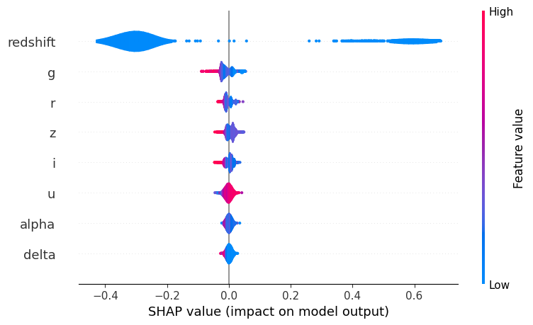

```
SHAP Summary Plot for Class 1
```

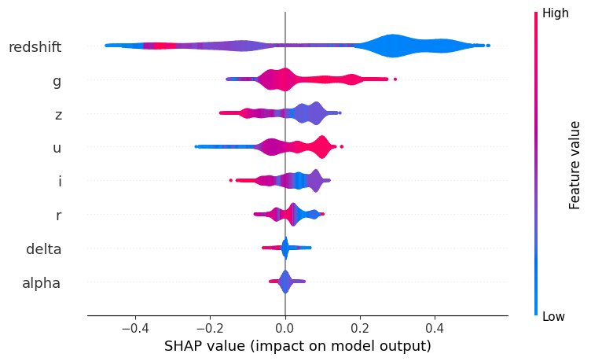

```
SHAP Summary Plot for Class 2
```

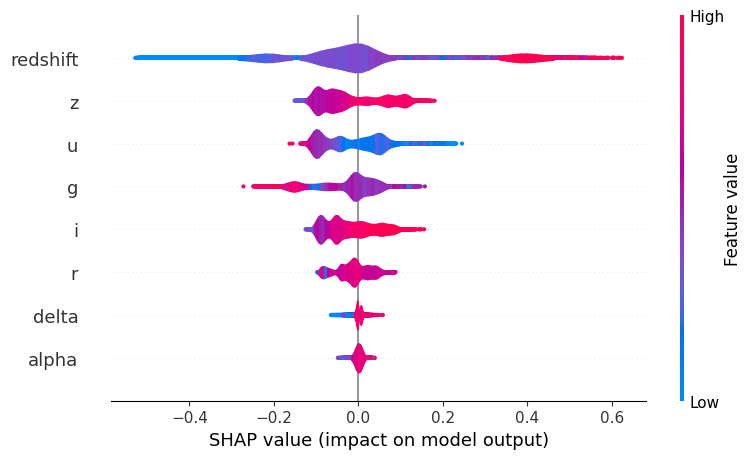

```python
for i in range(shap_values.shape[2]):
    print('SHAP Summary Plot for Class {}'.format(i))
    shap.summary_plot(shap_values[:,:,i], x_test,plot_type='violin')
```

Shap value show that the redshift is the variable that impacts the most on the classification result

We can have a look to a individual case to observe how the different variables alter the baseline prediction of the model (average over the whole test set)

If we pick a Quasar

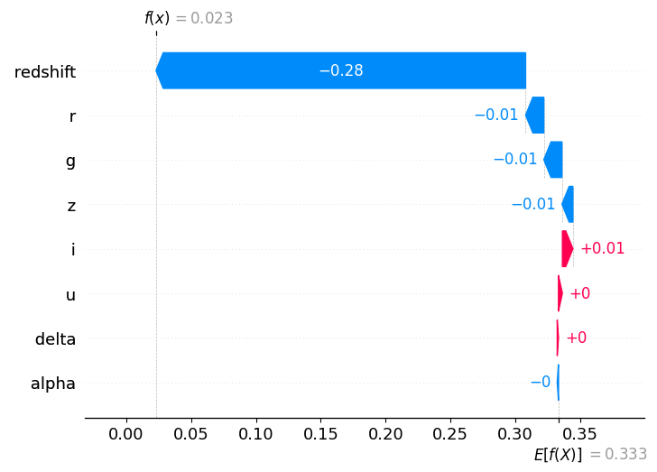

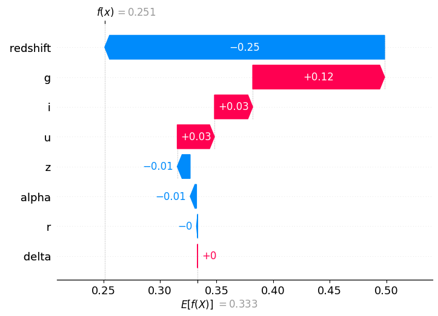

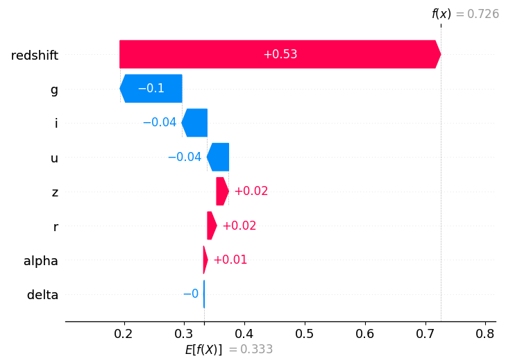

```python
i=157

shap.plots._waterfall.waterfall_legacy(explainer.expected_value[0], shap_values[i,:,0], x_test.values[i-1], x_test.columns)
shap.plots._waterfall.waterfall_legacy(explainer.expected_value[0], shap_values[i,:,1], x_test.values[i-1], x_test.columns)
shap.plots._waterfall.waterfall_legacy(explainer.expected_value[0], shap_values[i,:,2], x_test.values[i-1], x_test.columns)
```

If we pick a Star

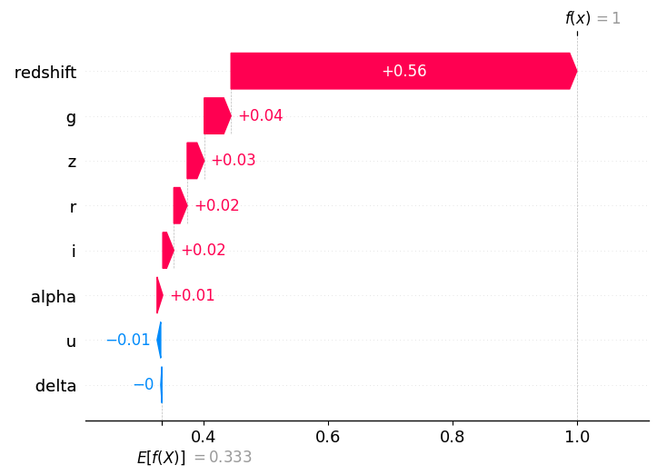

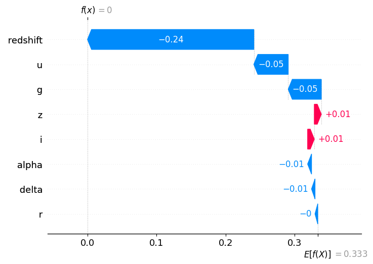

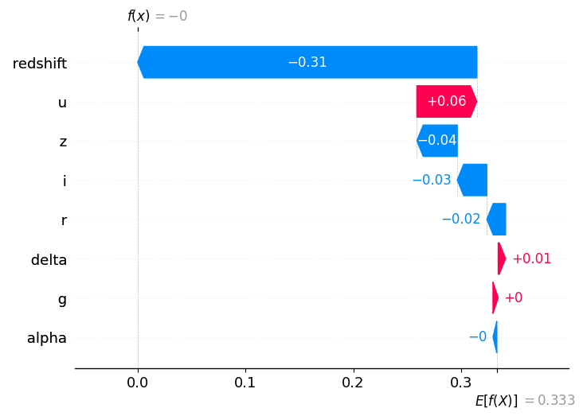

```python
i=11

shap.plots._waterfall.waterfall_legacy(explainer.expected_value[0], shap_values[i,:,0], x_test.values[i], x_test.columns, max_display=20)
shap.plots._waterfall.waterfall_legacy(explainer.expected_value[0], shap_values[i,:,1], x_test.values[i], x_test.columns, max_display=20)
shap.plots._waterfall.waterfall_legacy(explainer.expected_value[0], shap_values[i,:,2], x_test.values[i], x_test.columns, max_display=20)
```

If we pick a galaxy

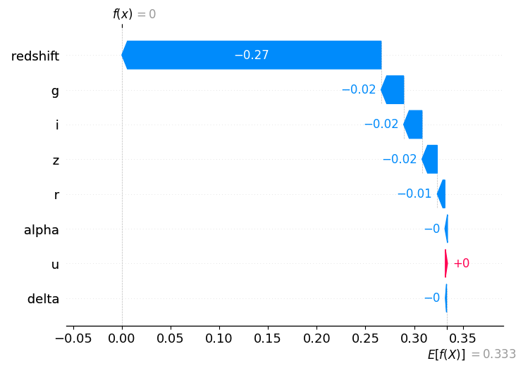

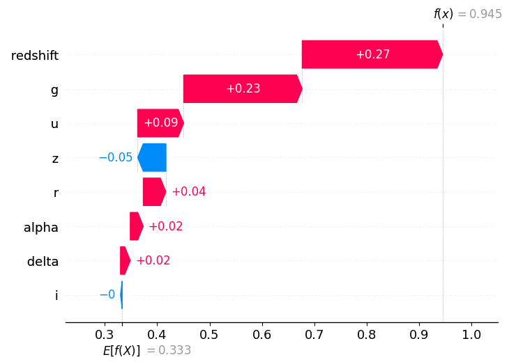

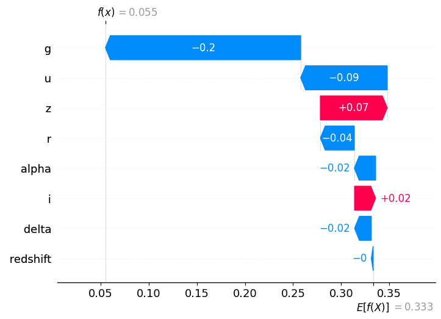

```python
i=3

shap.plots._waterfall.waterfall_legacy(explainer.expected_value[0], shap_values[i,:,0], x_test.values[i], x_test.columns, max_display=20)
shap.plots._waterfall.waterfall_legacy(explainer.expected_value[0], shap_values[i,:,1], x_test.values[i], x_test.columns, max_display=20)
shap.plots._waterfall.waterfall_legacy(explainer.expected_value[0], shap_values[i,:,2], x_test.values[i], x_test.columns, max_display=20)
```

The model is identying the mayority of the objects properly, but is the model making the same errors for all the classes?

#### Error per class

```python
total_instances_per_class = np.sum(matrix, axis=1)

error_rate_per_class = np.zeros(len(total_instances_per_class))
for i in range(len(total_instances_per_class)):
    error_rate_per_class[i] = (total_instances_per_class[i] - matrix[i, i]) / total_instances_per_class[i]

for cls, error_rate in zip([0,1,2], error_rate_per_class):
    print(f"Error Rate for Class {cls}: {error_rate:.4f}")
```

```
Error Rate for Class 0: 0.0000
Error Rate for Class 1: 0.0331
Error Rate for Class 2: 0.0524
```

The model is doing really well with stars (class 0), but it is presentig more problems with quasars (class 2)

#### Precision-Recall curves

We can have a look at the Precission-Recall curves generated for each class (one vs all)

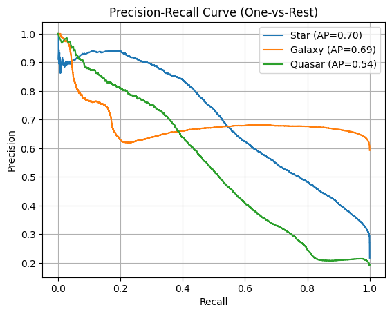

```python
y_test_bin = label_binarize(y_test, classes=[0, 1, 2])
y_probs = model.predict_proba(x_test)

for i, class_name in enumerate(['Star', 'Galaxy', 'Quasar']):
    precision, recall, _ = precision_recall_curve(y_test_bin[:, i], y_probs[:, i])
    ap = average_precision_score(y_test_bin[:, i], y_probs[:, i])
    plt.plot(recall, precision, label=f"{class_name} (AP={ap:.2f})")

plt.xlabel('Recall')
plt.ylabel('Precision')
plt.title('Precision-Recall Curve (One-vs-Rest)')
plt.legend()
plt.grid()
plt.show()
```

The average precission shows how the stars are the easiest object to clasify, meanwhile quasars are the most challenging. Looking at the curves, the quasars show how the precission falls quickly as the recall increases showing the existance of false positives, mainly comming from Galaxies misclassified.

#### Modifying the classification thresholds

To try to improve the identification of the quasars let's calculate the f1 score, which balances the precission and the recall of the classification. The thersholds of the probability that provide the best f1 results willl be used in the model

```python
y_true_bin = label_binarize(y_test, classes=[0, 1, 2])

precision_micro, recall_micro, _ = precision_recall_curve(y_true_bin.ravel(), y_proba.ravel())
ap_micro = average_precision_score(y_true_bin, y_proba, average='micro')
```

```python
best_thresholds = []
for i in range(y_proba.shape[1]):
    precision, recall, thresholds = precision_recall_curve(y_true_bin[:, i], y_proba[:, i])
    f1 = 2 * (precision * recall) / (precision + recall + 1e-8)
    best_idx = f1.argmax()
    best_thresholds.append((thresholds[best_idx], f1[best_idx]))
```

```python
best_thresholds
```

```
[(0.8281145917466248, 0.9961354385038932),
 (0.25304122239416355, 0.9781197674994914),
 (0.5917689497203564, 0.9411640161642228)]
```

```python
custom_thresholds = [0.828, 0.253, 0.591]
```

We use these thersholds in the Random Forest Classifier to assign the classes to each of the objects

```python
clf_cust = RandomForestClassifier()
clf_cust.fit(x_train, y_train)
```

```
RandomForestClassifier()
```

```python
y_proba = clf.predict_proba(x_test)
```

```python
def apply_custom_thresholds(y_proba, thresholds):
    predictions = []
    for probs in y_proba:
        above_thresh = [i for i, p in enumerate(probs) if p >= thresholds[i]]
        if len(above_thresh) == 1:
            predictions.append(above_thresh[0])
        elif len(above_thresh) > 1:
            # Pick the one with highest probability
            predictions.append(above_thresh[np.argmax([probs[i] for i in above_thresh])])
        else:
            predictions.append(np.argmax(probs))
    return np.array(predictions)

y_pred_custom = apply_custom_thresholds(y_proba, custom_thresholds)
```

```python
matrix = confusion_matrix(y_test, y_pred_custom)
accur= metrics.accuracy_score(y_test, y_pred_custom)

print(matrix, accur)
```

```
[[ 5421     0     0]
 [   71 14504   249]
 [    1   307  4447]] 0.97488
```

```python
total_instances_per_class = np.sum(matrix, axis=1)

error_rate_per_class = np.zeros(len(total_instances_per_class))
for i in range(len(total_instances_per_class)):
    error_rate_per_class[i] = (total_instances_per_class[i] - matrix[i, i]) / total_instances_per_class[i]

for cls, error_rate in zip([0,1,2], error_rate_per_class):
    print(f"Error Rate for Class {cls}: {error_rate:.4f}")
```

```
Error Rate for Class 0: 0.0000
Error Rate for Class 1: 0.0216
Error Rate for Class 2: 0.0648
```

We can compare these results with what we had before modifying the hyperparametes:

Confussion Matrix:  
[[ 5421 0 0]  
[ 134 14334 356]  
[ 1 248 4506]]

Error Rate for Class 0: 0.0000  
Error Rate for Class 1: 0.0331  
Error Rate for Class 2: 0.0524

The error of the galaxy class (class 1) is now smaller, however the error of the quasars class (class 2) is bigger.

Choosing between the original thersholds of these ones proposed here would depend on the scientific goal. But, considering that the quasars are a more rare object and their number is smaller in the data we will prioritaze its correct detection. Therefore, we will consider the original thersholds and we will use them to implement the model

## Conclussions

The study of the data has shown that the redshift is the variable with the biggest impact on the data and that the Random Forest is the best algorithm to classify the data. The results can also be modify changing the decission thersholds but that would depend on the scintific goals and which objects are more valuable for the investigators

I will develop a script to launch in python in which the user would be able to choose between the two best performance models (Random Forest or SVM). The program will allow also to save the model, and to run in two modes: production or evaluation, depending on the goal: to generate prediction for new data or to evaluate the models performance